# We load necessary libraries an download the data set, unzip it and reading it using read.csv #command

```r
library(dplyr)
library(lubridate)
library(knitr)
```

```r
library(ggplot2)
df<- read.csv("./activity.csv",stringsAsFactors = FALSE)
```

Converting the df into dplyr table data frame

```r
df<- tbl_df(df)
```

converting df$date into lubridate date format: year, month, day

```r
df$date <- ymd(df$date)
```

grouping by date

```r
df_by_date<- group_by(df, date)
```

Summarising by mean value of steps per day

```r
df_by_date_mean<- summarise(df_by_date, mean(steps))
```

Calculate the total number of steps taken per day

```r
df_by_date_total <- summarise(df_by_date, total =sum(steps))
```

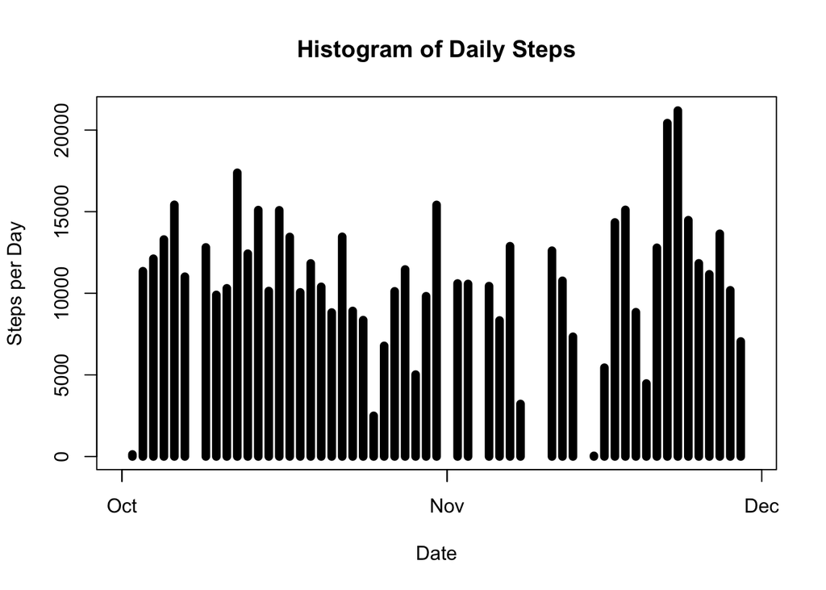

```r
plot(df_by_date_total$date, df_by_date_total$total, type="h", main="Histogram of Daily Steps",xlab="Date", ylab="Steps per Day", col="black", lwd=7)
```

Calculate and report the mean and median of the total number of steps taken per day

mean

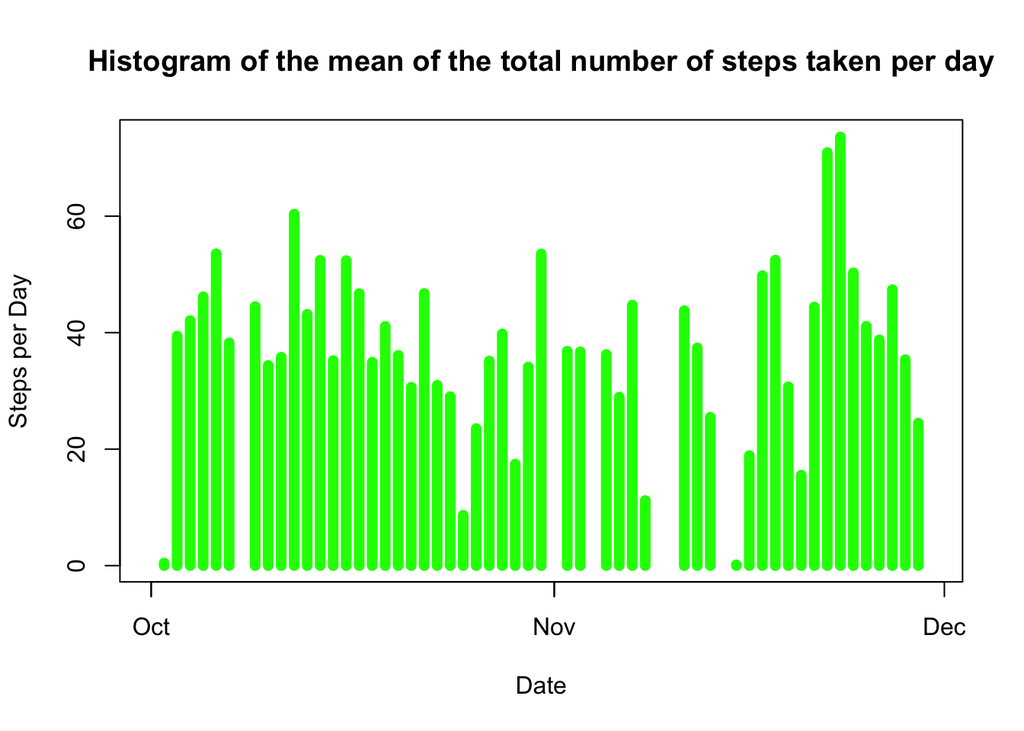

```r
df_by_date_mean<- summarise(df_by_date, mean(steps))
plot(df_by_date_mean$date, df_by_date_mean$mean, type="h", main="Histogram of the mean of the total number of steps taken per day",xlab="Date", ylab="Steps per Day", col="green", lwd=7)
```

```r
h=mean(df_by_date_total$total)
cat("Mean of Total number of steps taken per day =", h)
```

```
## Mean of Total number of steps taken per day = NA
```

median

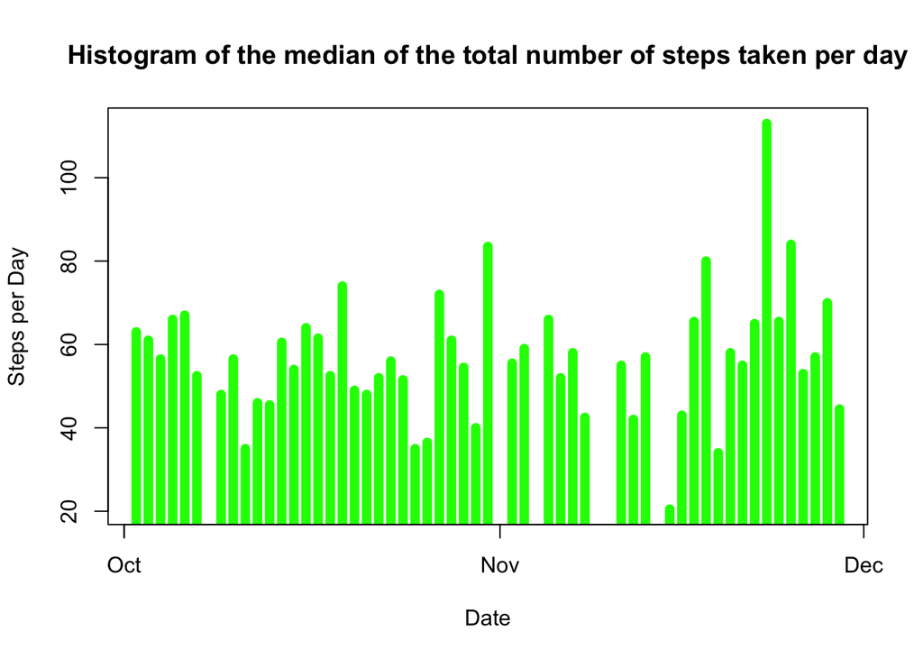

```r
df_by_date_median<- df_by_date%>%filter(steps != 0)%>%summarise(median(steps))

plot(df_by_date_median$date, df_by_date_median$median, type="h", main="Histogram of the median of the total number of steps taken per day",xlab="Date", ylab="Steps per Day", col="green", lwd=7)
```

```r
m=median(df_by_date_total$total)
cat("Median of Total number of steps taken per day =", m)
```

```
## Median of Total number of steps taken per day = NA
```

Make a time series plot (i.e. type = “l”) of the 5-minute interval (x-axis) and the average number of steps taken, averaged across all days (y-axis)

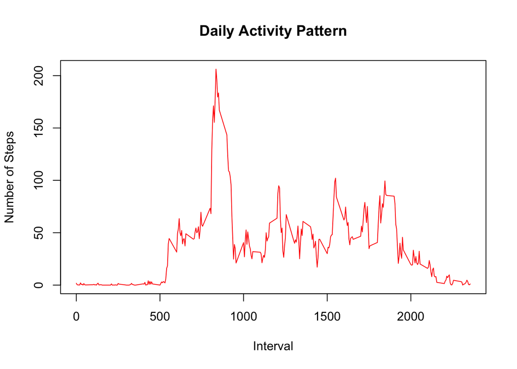

```r
df_no_na <- df[complete.cases(df), ]

steps_av <- aggregate(df_no_na$steps, list(as.numeric(df_no_na$interval)), FUN="mean")

steps_av <- rename(steps_av, interval=Group.1, mean=x)

plot(steps_av, type="l", xlab="Interval", ylab="Number of Steps", main="Daily Activity Pattern", col=2)
```

Which 5-minute interval, on average across all the days in the dataset, contains the maximum number of steps?

```r
filter(steps_av, mean==max(mean))
```

```
##   interval     mean
## 1      835 206.1698
```

Calculate and report the total number of missing values in the dataset (i.e. the total number of rows with NAs)

```r
total_na <- sum(is.na(df))

cat("Total number of missing values in the dataset=", total_na)
```

```
## Total number of missing values in the dataset= 2304
```

Devise a strategy for filling in all of the missing values in the dataset. The strategy does not need to be sophisticated. For example, you could use the mean/median for that day, or the mean for that 5-minute interval, etc. Create a new dataset that is equal to the original dataset but with the missing data filled in.

the strategy is to relace NAs with the median for 5 min interval where there NAs are located. the converted data set will be storen in df_no_NA data frame.

```r
df_no_Na <- df
df_no_Na$steps[is.na(df_no_Na$steps)] <- with(df_no_Na, ave(steps, interval, FUN = function(x) median(x, na.rm = TRUE)))[is.na(df_no_Na$steps)]

sum(is.na(df_no_Na))
```

```
## [1] 0
```

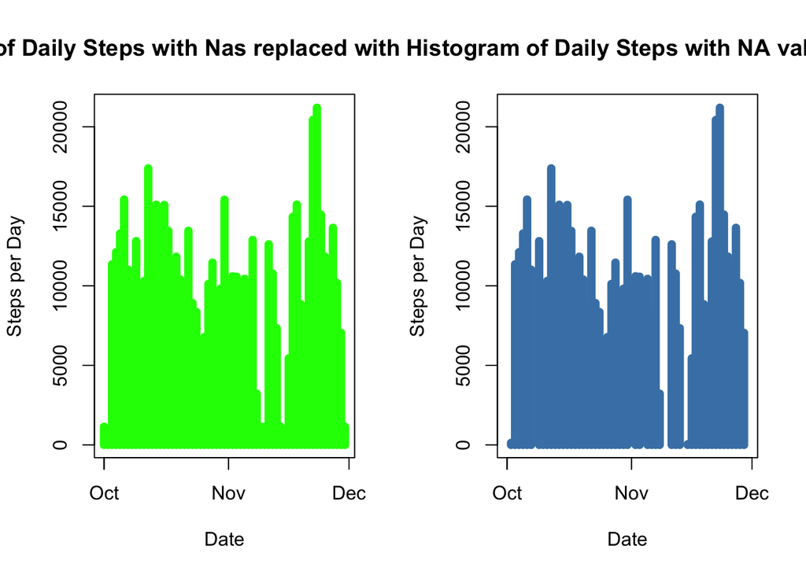

```r
df_no_Na_by_day <- group_by(df_no_Na, date)

df_no_Na_by_day_total <- summarise(df_no_Na_by_day, total=sum(steps))


old.par <- par(mfrow=c(1, 2))
plot(df_no_Na_by_day_total$date, df_no_Na_by_day_total$total, type="h", main="Histogram of Daily Steps with Nas replaced with interval median",xlab="Date", ylab="Steps per Day", col="green", lwd=7)
plot(df_by_date_total$date, df_by_date_total$total, type="h", main="Histogram of Daily Steps with NA values",xlab="Date", ylab="Steps per Day", col="steelblue", lwd=7)
```

```r
par(old.par)
```

mean

```r
b=mean(df_no_Na_by_day_total$total)
cat("Mean of Total number of steps taken per day with NAs replaced =", b)
```

```
## Mean of Total number of steps taken per day with NAs replaced = 9503.869
```

```r
cat("Mean of Total number of steps taken per day =", h)
```

```
## Mean of Total number of steps taken per day = NA
```

median

```r
n=median(df_no_Na_by_day_total$total)
cat("Median of Total number of steps taken per day =", n)
```

```
## Median of Total number of steps taken per day = 10395
```

```r
cat("Median of Total number of steps taken per day =", m)
```

```
## Median of Total number of steps taken per day = NA
```

Create a new factor variable in the dataset with two levels – “weekday” and “weekend” indicating whether a given date is a weekday or weekend day

```r
wDays <- c("Monday", "Tuesday", "Wednesday", "Thursday", "Friday")


df_no_Na$wDays <- factor((weekdays(df_no_Na$date) %in% wDays),
                  levels=c(FALSE, TRUE), labels=c('weekend', 'weekday'))
```

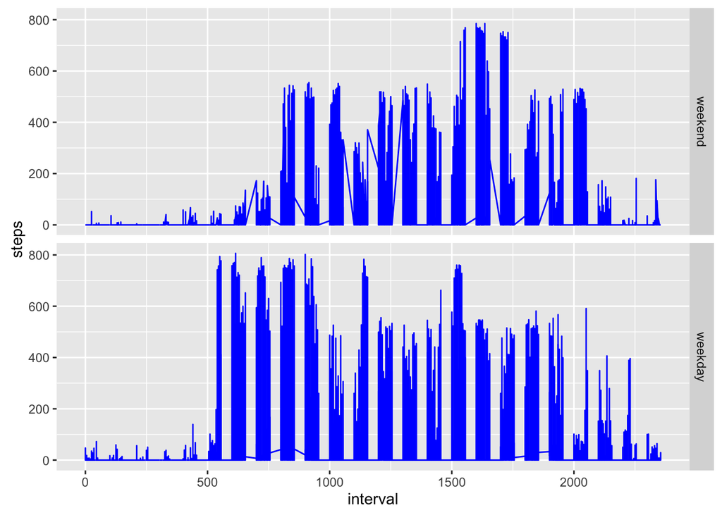

```r
t <- ggplot(df_no_Na, aes(interval, steps))
t + geom_line(color="blue") + facet_grid(wDays~.)
```

End of Reproducible Reaserch Course Project 1